# Random Forest

## Clasificación

Los bosques aleatorios (Random Forest) son métodos de aprendizaje automático bastante versátil que puede realizar tanto clasificaciones como tareas de regresión, permitiendo trabajar con muestreo con reemplazamiento (bootstrap); basicamente es un conjunto de árboles de decisión.

```python
import os
os.chdir('C:\\Users\\GalindezR\\Desktop\\Personal\\random_forest')
```

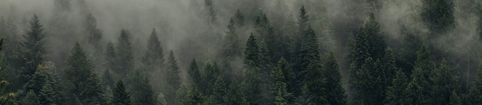

```python
from IPython.display import Image
Image(".//img//forest__.jpg")
```

En este ejemplo usaremos esta técnica para clasificar una serie de vinos dados ciertas características de los mismos

El dataset es el resultado de un análisis químico de vinos cultivados en una misma región en Italia pero derivados de tres cultivares diferentes. El análisis determinó las cantidades de 13 constituyentes que se encuentran en cada uno de los tres tipos de vinos.

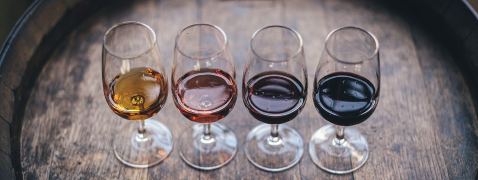

```python
Image(".//img//wines__.jpg")
```

**Importamos las librerías**

```python
import pandas as pd
import numpy as np
import matplotlib as plt
import seaborn as sns
```

**Cargamos nuestro dataset**

```python
vinos = pd.read_csv('.//data//wine_dataset.csv')
```

**Definimos nuestro conjunto de variables explicativas**

```python
X = vinos.drop('Wine Type', axis=1)
```

**Definimos nuestra variable de clasificación a predecir**

```python
y = vinos['Wine Type']
```

Cargamos la librería necesaria para hacer el split de nuestro data en training y testing data

```python
from sklearn.model_selection import train_test_split
```

```python
X_train, X_test, y_train, y_test = train_test_split(X,y, test_size = .3)
```

**Entrenamos nuestro modelo**

```python
from sklearn.ensemble import RandomForestClassifier
```

```python
randomforest = RandomForestClassifier()
```

```python
randomforest.fit(X_train, y_train)
```

```
RandomForestClassifier(bootstrap=True, ccp_alpha=0.0, class_weight=None,
                       criterion='gini', max_depth=None, max_features='auto',
                       max_leaf_nodes=None, max_samples=None,
                       min_impurity_decrease=0.0, min_impurity_split=None,
                       min_samples_leaf=1, min_samples_split=2,
                       min_weight_fraction_leaf=0.0, n_estimators=100,
                       n_jobs=None, oob_score=False, random_state=None,
                       verbose=0, warm_start=False)
```

Predecimos el tipo de vino para nuestra data de test

```python
predicciones = randomforest.predict(X_test)
```

```python
predicciones
```

```
array(['One', 'One', 'One', 'Three', 'One', 'Three', 'One', 'Two', 'Two',
       'One', 'One', 'One', 'Three', 'Two', 'Two', 'Three', 'Three',
       'Two', 'Two', 'Two', 'Three', 'One', 'One', 'Three', 'One',
       'Three', 'Three', 'Two', 'Three', 'Two', 'Two', 'One', 'Three',
       'Three', 'One', 'One', 'Two', 'Three', 'Two', 'Three', 'Two',
       'One', 'Three', 'Two', 'Two', 'One', 'One', 'Two', 'Three', 'Two',
       'Two', 'Two', 'Two', 'Three'], dtype=object)
```

```python
y_test
```

```
51       One
49       One
37       One
61       Two
55       One
161    Three
40       One
90       Two
121      Two
34       One
12       One
3        One
130    Three
88       Two
101      Two
```

[output cut: 40 more lines]

**Evaluación del modelo**

```python
from sklearn.metrics import classification_report, confusion_matrix
```

```python
print(classification_report(y_test, predicciones))
```

```
              precision    recall  f1-score   support

         One       1.00      1.00      1.00        17
       Three       0.88      1.00      0.94        15
         Two       1.00      0.91      0.95        22

    accuracy                           0.96        54
   macro avg       0.96      0.97      0.96        54
weighted avg       0.97      0.96      0.96        54
```

**Matriz de confusión**

```python
print(confusion_matrix(y_test, predicciones))
```

```
[[17  0  0]
 [ 0 15  0]
 [ 0  2 20]]
```